# Self-Driving Car Engineer Nanodegree

## Project: Build a Traffic Sign Recognition Classifier

```python
import os
import pickle
from collections import Counter

import numpy as np
import pandas as pd
import matplotlib.pyplot as plt
import matplotlib.image as mpimage

import tensorflow as tf
from tensorflow.contrib.layers import flatten
from sklearn.utils import shuffle
from sklearn import preprocessing
from sklearn.metrics import confusion_matrix, classification_report

# Visualizations will be shown in the notebook.
%matplotlib inline
```

## Load The Data

The pickled data is a dictionary with 4 key/value pairs:

- `'features'` is a 4D array containing raw pixel data of the traffic sign images, (num examples, width, height, channels).
- `'labels'` is a 1D array containing the label/class id of the traffic sign. The file `signnames.csv` contains id -> name mappings for each id.
- `'sizes'` is a list containing tuples, (width, height) representing the original width and height the image.
- `'coords'` is a list containing tuples, (x1, y1, x2, y2) representing coordinates of a bounding box around the sign in the image. **THESE COORDINATES ASSUME THE ORIGINAL IMAGE. THE PICKLED DATA CONTAINS RESIZED VERSIONS (32 by 32) OF THESE IMAGES**

```python
# Load pickled data

training_file = 'data/train.p'
validation_file = 'data/valid.p'
testing_file = 'data/test.p'

with open(training_file, mode='rb') as f:
    train = pickle.load(f)
with open(validation_file, mode='rb') as f:
    valid = pickle.load(f)
with open(testing_file, mode='rb') as f:
    test = pickle.load(f)

X_train_raw, y_train_raw = train['features'], train['labels']
X_valid_raw, y_valid_raw = valid['features'], valid['labels']
X_test_raw, y_test_raw = test['features'], test['labels']

label_desc = pd.read_csv('signnames.csv')['SignName'].tolist()
```

## Dataset Summary & Exploration

### Basic Summary of the Data Set

```python
# Number of training examples
n_train = len(X_train_raw)
# Number of validation examples
n_validation = len(X_valid_raw)
# Number of testing examples.
n_test = len(X_test_raw)
# shape of an traffic sign image?
image_shape = X_train_raw[0].shape
# unique classes/labels there are in the dataset
n_classes = len(set(y_train_raw))

print("Number of training examples =", n_train)
print("Number of validation examples =", n_validation)
print("Number of testing examples =", n_test)
print("Image data shape =", image_shape)
print("Number of classes =", n_classes)
```

```
Number of training examples = 34799
Number of validation examples = 4410
Number of testing examples = 12630
Image data shape = (32, 32, 3)
Number of classes = 43
```

### Exploratory visualization of the dataset

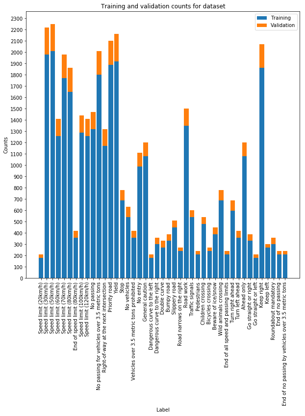

```python
# counts of each sign for training and validation
training_counts = Counter(y_train_raw)
validation_counts = Counter(y_valid_raw)

labels = list(training_counts.keys())
training_counts = [training_counts[x] for x in labels]
validation_counts = [validation_counts[x] for x in labels]

fig = plt.figure(0, figsize=(10,10))

p1 = plt.bar(labels, training_counts)
p2 = plt.bar(labels, validation_counts, bottom=training_counts )
plt.ylabel('Counts')
plt.xlabel('Label')
plt.title('Training and validation counts for dataset')
plt.xticks(labels, label_desc, rotation=90)
plt.yticks(np.arange(0, 2400, 100))
plt.legend((p1[0], p2[0]), ('Training', 'Validation'))
plt.show()
```

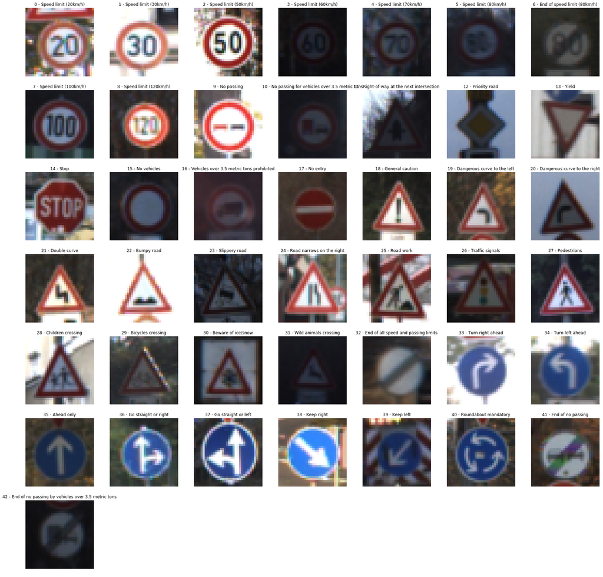

```python
# display each sign so we know what we are looking at
fig = plt.figure(1, (30,30))
for x in range(n_classes):
    plt.subplot(7,7,x+1)
    plt.title('{} - {}'.format(x, label_desc[x]))
    plt.axis('off')
    plt.imshow(X_train_raw[np.where(y_train_raw==x)][77])
```

## Design and Test a Model Architecture

Design and implement a deep learning model that learns to recognize traffic signs. Train and test your model on the [German Traffic Sign Dataset](http://benchmark.ini.rub.de/?section=gtsrb&subsection=dataset).

### Pre-process the Data Set

```python
# rgb to gray
def rgb2gray(rgb):
    return np.expand_dims(np.dot(rgb[...,:3], [0.299, 0.587, 0.114]), axis=3)

X_train_gray = rgb2gray(X_train_raw)
X_valid_gray = rgb2gray(X_valid_raw)
X_test_gray = rgb2gray(X_test_raw)
```

```python
# normalize dataset
X_train_tmp = X_train_gray.reshape(X_train_gray.shape[0],-1)
X_valid_tmp = X_valid_gray.reshape(X_valid_gray.shape[0],-1)
X_test_tmp = X_test_gray.reshape(X_test_gray.shape[0], -1)

minmax_scale = preprocessing.MinMaxScaler().fit(X_train_tmp)
X_train_norm = minmax_scale.transform(X_train_tmp).reshape(X_train_gray.shape)
X_valid_norm = minmax_scale.transform(X_valid_tmp).reshape(X_valid_gray.shape)
X_test_norm = minmax_scale.transform(X_test_tmp).reshape(X_test_gray.shape)
```

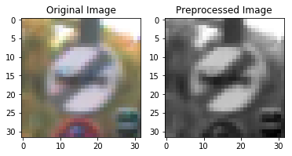

```python
plt.subplot(1,2,1)
plt.title('Original Image')
plt.imshow(X_train_raw[100])
plt.subplot(1,2,2)
plt.title('Preprocessed Image')
plt.imshow(X_train_norm[100].squeeze(), cmap='gray')
```

### Model Architecture

```python
### Define your architecture here.
### Feel free to use as many code cells as needed.
def conv2d(x, channels_in, channels_out, filter_size=5, stride=1, padding='VALID', name="conv"):
    with tf.name_scope(name):
        w = tf.Variable(tf.truncated_normal(mean=0, stddev=0.1, shape=[filter_size,filter_size,channels_in,channels_out]), name="W")
        b = tf.Variable(tf.zeros(channels_out), name="B")
        conv = tf.nn.conv2d(x, w, [1,stride,stride,1], padding)
        conv = tf.nn.bias_add(conv, b)
        return tf.nn.relu(conv)

def max_pooling(x, s=2):
    return tf.nn.max_pool(x, ksize=[1,s,s,1], strides=[1,s,s,1], padding='VALID')

def fc(x, channels_in, channels_out, name="fc"):
    with tf.name_scope(name):
        w = tf.Variable(tf.truncated_normal(mean=0, stddev=0.1, shape=(channels_in,channels_out)), name="W")
        b = tf.Variable(tf.zeros(channels_out), name="B")
        return tf.matmul(x, w) + b

def fc_with_relu(x, channels_in, channels_out, name="fc"):
    with tf.name_scope(name):
        w = tf.Variable(tf.truncated_normal(mean=0, stddev=0.1, shape=(channels_in,channels_out)), name="W")
        b = tf.Variable(tf.zeros(channels_out), name="B")
        return tf.nn.relu(tf.matmul(x, w) + b)

def LeNet(x):
    # 32x32x1 -> 32x32x30
    conv1 = conv2d(x, channels_in=1, channels_out=30, name="conv1")
    conv1 = tf.nn.dropout(conv1, keep_prob)

    # 32x32x30 -> 14x14x30
    conv2 = conv2d(conv1, channels_in=30, channels_out=30, stride=2, padding='SAME', name="conv2")
    conv2 = tf.nn.dropout(conv2, keep_prob)

    # 14x14x30 -> 5x5x64
    conv3 = conv2d(conv2, channels_in=30, channels_out=64, name="conv3")
    conv3 = max_pooling(conv3)
    conv3 = tf.nn.dropout(conv3, keep_prob)

    # 5x5x64 -> 1600
    fc0 = flatten(conv3)
    # 1600 -> 120
    fc1 = fc_with_relu(fc0, 1600, 400, name="fc1")
    fc1 = tf.nn.dropout(fc1, keep_prob)
    # 120 -> 84
    fc2 = fc_with_relu(fc1, 400, 84, name="fc2")
    fc2 = tf.nn.dropout(fc2, keep_prob)
    # 84 -> n_classes
    logits = fc(fc2, 84, n_classes, name="logits")
    return logits
```

### Train, Validate and Test the Model

A validation set can be used to assess how well the model is performing. A low accuracy on the training and validation sets imply underfitting. A high accuracy on the training set but low accuracy on the validation set implies overfitting.

```python
tf.reset_default_graph()

x = tf.placeholder(tf.float32, (None, 32, 32, 1), name="x")
y = tf.placeholder(tf.int32, (None), name="labels")
one_hot_y = tf.one_hot(y, n_classes)
keep_prob = tf.placeholder(tf.float32)
```

```python
rate = 0.001
EPOCHS = 20
BATCH_SIZE = 128
save_file = './model/traffic-sign-classifier'

logits = LeNet(x)

with tf.name_scope("xent"):
    cross_entropy = tf.nn.softmax_cross_entropy_with_logits(labels=one_hot_y, logits=logits)
    loss_operation = tf.reduce_mean(cross_entropy)

with tf.name_scope("train"):
    optimizer = tf.train.AdamOptimizer(learning_rate = rate)
    training_operation = optimizer.minimize(loss_operation)
```

```python
with tf.name_scope("accuracy"):
    correct_prediction = tf.equal(tf.argmax(logits, 1), tf.argmax(one_hot_y, 1))
    accuracy_operation = tf.reduce_mean(tf.cast(correct_prediction, tf.float32))

saver = tf.train.Saver()

def evaluate(X_data, y_data):
    num_examples = len(X_data)
    total_accuracy = 0
    sess = tf.get_default_session()
    for offset in range(0, num_examples, BATCH_SIZE):
        batch_x, batch_y = X_data[offset:offset+BATCH_SIZE], y_data[offset:offset+BATCH_SIZE]
        accuracy = sess.run(accuracy_operation, feed_dict={x: batch_x, y: batch_y, keep_prob: 1.0})
        total_accuracy += (accuracy * len(batch_x))
    return total_accuracy/num_examples
```

```python
with tf.Session() as sess:
    sess.run(tf.global_variables_initializer())

    num_examples = len(X_train_raw)

    print("Training...")
    print()
    for i in range(EPOCHS):
        X_train, y_train = shuffle(X_train_norm, y_train_raw)
        for offset in range(0, num_examples, BATCH_SIZE):
            end = offset + BATCH_SIZE
            batch_x, batch_y = X_train[offset:end], y_train[offset:end]
            sess.run(training_operation, feed_dict={x: batch_x, y: batch_y, keep_prob:0.5})

        validation_accuracy = evaluate(X_valid_norm, y_valid_raw)
        print("EPOCH {} ...".format(i+1))
        print("Validation Accuracy = {:.3f}".format(validation_accuracy))
        print()

    saver.save(sess, './traffic-sign-classifier')
    print("Model saved")
```

```
Training...

EPOCH 1 ...
Validation Accuracy = 0.045

EPOCH 2 ...
Validation Accuracy = 0.086

EPOCH 3 ...
Validation Accuracy = 0.183

EPOCH 4 ...
Validation Accuracy = 0.470

EPOCH 5 ...
Validation Accuracy = 0.705

EPOCH 6 ...
Validation Accuracy = 0.804

EPOCH 7 ...
Validation Accuracy = 0.856

EPOCH 8 ...
Validation Accuracy = 0.879

EPOCH 9 ...
Validation Accuracy = 0.907

EPOCH 10 ...
Validation Accuracy = 0.911

EPOCH 11 ...
Validation Accuracy = 0.915

EPOCH 12 ...
Validation Accuracy = 0.931

EPOCH 13 ...
Validation Accuracy = 0.942
```

[output cut: 8 more lines]

```
Validation Accuracy = 0.954

EPOCH 17 ...
Validation Accuracy = 0.957

EPOCH 18 ...
Validation Accuracy = 0.959

EPOCH 19 ...
Validation Accuracy = 0.965

EPOCH 20 ...
Validation Accuracy = 0.963

Model saved
```

```python
with tf.Session() as sess:
    saver.restore(sess, tf.train.latest_checkpoint('.'))
    validation_accuracy = evaluate(X_valid_norm, y_valid_raw)
    print(validation_accuracy)
```

```
INFO:tensorflow:Restoring parameters from ./traffic-sign-classifier
0.963265306122449
```

#### Model change summary

| Changes | Accuracy |
| --- | --- |
| Generic Lenet | 0.891 |
| Added normalization | 0.902 |
| Added grayscale | 0.909 |
| Changed conv layer depth to 30-64 | 0.934 |
| Added dropout | 0.959 |
| **Replaced 1st max pooling with conv layer with stride=2** | **0.963** |

## Test a Model on New Images

### Load and Output the Images

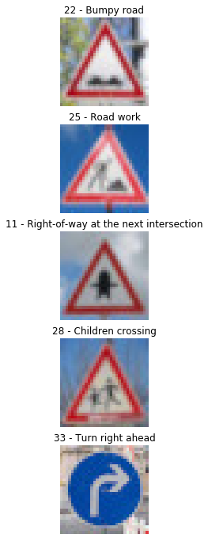

```python
# Load the images
test_path = 'test_images'
test_images = [mpimage.imread(os.path.join(test_path, f)) for f in os.listdir(test_path) if os.path.isfile(os.path.join(test_path, f))]
labels = [int(f.split('.')[0]) for f in os.listdir(test_path) if os.path.isfile(os.path.join(test_path, f))]

# plot images
fig = plt.figure(figsize=(2,12))
for idx in range(len(test_images)):
    plt.subplot(5,1,idx+1)
    plt.axis('off')
    plt.title("{} - {}".format(labels[idx], label_desc[labels[idx]]))
    plt.imshow(test_images[idx])
```

### Predict the Sign Type for Each Image

```python
# preprocess images
gray = np.array([rgb2gray(img) for img in test_images])
gray_norm = minmax_scale.transform(gray.reshape(gray.shape[0],-1)).reshape(gray.shape)

# classify
classification = None
top_5 = None
with tf.Session() as sess:
    saver.restore(sess, tf.train.latest_checkpoint('.'))
    classification = sess.run(tf.nn.softmax(logits),
                              feed_dict={x: gray_norm, y: 0, keep_prob: 1.0})
    top_5 = sess.run(tf.nn.top_k(classification, k=5))
```

```
INFO:tensorflow:Restoring parameters from ./traffic-sign-classifier
```

### Analyze Performance

```python
### Calculate the accuracy for these 5 new images.
### For example, if the model predicted 1 out of 5 signs correctly, it's 20% accurate on these new images.
accuracy = 0
prediction = np.argmax(classification,axis=1)

for idx in range(len(prediction)):
    print("Actual: {} | Prediction: {}".format(labels[idx], prediction[idx]))
    accuracy += 1

print()
print("Accuracy: {:.2f}".format(accuracy/len(prediction)*100))
```

```
Actual: 22 | Prediction: 22
Actual: 25 | Prediction: 25
Actual: 11 | Prediction: 11
Actual: 28 | Prediction: 28
Actual: 33 | Prediction: 33

Accuracy: 100.00
```

#### Output Top 5 Softmax Probabilities For Each Image

```python
probs = top_5[0]
preds = top_5[1]

for i in range(len(labels)):
    print('Image {}:'.format(i+1))
    for j in range(5):
        print('  {}: {:.10f}'.format(preds[i][j], probs[i][j]))
```

```
Image 1:
  22: 1.0000000000
  29: 0.0000000358
  26: 0.0000000073
  36: 0.0000000003
  18: 0.0000000000
Image 2:
  25: 0.9999899864
  31: 0.0000064840
  22: 0.0000013956
  20: 0.0000011502
  38: 0.0000003622
Image 3:
  11: 0.9993440509
  30: 0.0006556586
  27: 0.0000001558
  21: 0.0000001366
  40: 0.0000000000
Image 4:
  28: 0.9999381304
  20: 0.0000524217
  29: 0.0000093365
  23: 0.0000000685
  30: 0.0000000356
Image 5:
  33: 1.0000000000
  35: 0.0000000375
  37: 0.0000000053
  14: 0.0000000051
  40: 0.0000000004
```

### Testing on the test set

```python
print("Number of test images:", n_test)

y_pred = []
with tf.Session() as sess:
    saver.restore(sess, tf.train.latest_checkpoint('.'))
    for offset in range(0, n_test, BATCH_SIZE):
        batch_x = X_test_norm[offset:offset+BATCH_SIZE]
        classification = sess.run(tf.nn.softmax(logits),
                                  feed_dict={x: batch_x, y: 0, keep_prob: 1.0})
        y_pred.extend(np.argmax(classification,axis=1))

assert len(y_pred) == n_test
```

```
Number of test images: 12630
INFO:tensorflow:Restoring parameters from ./traffic-sign-classifier
```

## Analysis

```python
test_accuracy = np.sum(np.array(y_pred) == y_test_raw) / n_test
print("Test accuracy:", test_accuracy*100)
```

```
Test accuracy: 94.71100554235946
```

### Confusion Matrix

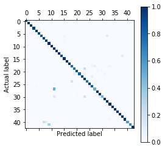

```python
cm = confusion_matrix(y_test_raw, y_pred)
cm = cm.astype('float') / cm.sum(axis=1)[:, np.newaxis] # normalize
plt.matshow(cm, interpolation='nearest', cmap=plt.cm.Blues)
plt.colorbar()
plt.xlabel("Predicted label")
plt.ylabel("Actual label")
```

### Classification Report

[Learn](https://machinelearningmastery.com/classification-accuracy-is-not-enough-more-performance-measures-you-can-use/)

Precision: For images classified in class x, what percent actually belong to x $=\frac{TP}{TP+FP}$

Recall: For images in class x, how many were classified in x $=\frac{TP}{TP+FN}$

F1-score: $2*\frac{precision*recall}{precision+recall}$

```python
print(classification_report(y_test_raw, y_pred))
```

```
             precision    recall  f1-score   support

          0       1.00      0.87      0.93        60
          1       0.97      0.99      0.98       720
          2       0.96      0.98      0.97       750
          3       0.94      0.94      0.94       450
          4       0.97      0.97      0.97       660
          5       0.94      0.93      0.94       630
          6       1.00      0.85      0.92       150
          7       0.94      0.94      0.94       450
          8       0.92      0.95      0.94       450
          9       0.95      1.00      0.97       480
         10       0.99      1.00      0.99       660
         11       0.87      0.98      0.92       420
         12       0.98      0.99      0.98       690
```

[output cut: 32 more lines]